# Discovering My Own Music Taste

Author

Roos Zijlstra

# What determines my music taste?

> David Hume: “Taste is not a matter of reasoning, but of sentiment.”

Question: What music attributes determine my taste?

Rationale: Is our taste determined by objective music attributes? If that is the case, what are things I enjoy? Do I care about the instrumentality and valence or do I prioritise songs with a high tempo? Or.. do I not care about music attributes at all and is it a non-quantifiable feeling or image?

I will compare artists that I love, such as Blood Orange, The Strokes and Zimmer90, with artists that I can not get into, such as Ava Max, Mac DeMarco and Griff.

### My Favourite Artists:

Zimmer90:

[figure not shown]

[Zimmer90 - Millions](https://youtu.be/B_PuhFHEHzg?si=-OG0yDaM0giR05Js) 0:00 - 0:30

[video not shown]

Blood Orange:

[figure not shown]

[Blood Orange - The Complete Knock](https://youtu.be/8WrEg0StHpc?si=v7s9Bt66VX5CKHp6) 3:00 - 3:30

[video not shown]

The Strokes:

[figure not shown]

[The Strokes - At The Door](https://youtu.be/hniKC-2x3eI?si=v5ogss7MQaiAs6AV) 3:30 - 4:00

[video not shown]

### My Non-Favourite Artists:

Ava Max:

[figure not shown]

[Ava Max - Kings & Queens](https://youtu.be/jH1RNk8954Q?si=z9xf56D_ZJuEkqhM)

[video not shown]

Griff:

[figure not shown]

[Griff - Black Hole](https://youtu.be/B2SK_jb68dk?si=IwMy99G0mwvujK2R)

[video not shown]

Mac DeMarco:

[figure not shown]

[Mac DeMarco - My Kind of Woman](https://youtu.be/wIuBcb2T55Q?si=B5Bwr9skmA1tnITa)

[video not shown]

## Project Preparation:

Lets load the relevant packages and datasets!

```r
#these are the packages I need for the analysis
library(ggplot2)
library(dplyr)

# Check whether the file is located in the working directory as it gave an error.
getwd()
```

```
[1] "/Users/roos-aimeezijlstra/Desktop/r stuff/MyDataScienceProject"
```

```r
list.files()
```

```
 [1] "Adele.csv"                  "images"
 [3] "MyDataScienceProject.Rproj" "roosmusictaste.csv"
 [5] "Roosmusictaste.html"        "Roosmusictaste.qmd"
 [7] "Roostaste.qmd"              "RoosZmusictaste.html"
 [9] "RoosZmusictaste.qmd"        "RoosZmusictaste.rmarkdown"
[11] "Untitled.R"
```

```r
# Check whether data from the dataset can be imported now.
df <- read.csv("roosmusictaste.csv")

df <- read.csv("roosmusictaste.csv", stringsAsFactors = FALSE)
head(df)
```

```
                                  Song Acousticness Danceability Energy
1                          At The Door     0.858000        0.456  0.323
2                      Hard To Explain     0.000413        0.406  0.682
3                       Eternal Summer     0.014100        0.617  0.780
4                   The Complete Knock     0.001380        0.609  0.480
5                                 Wish     0.522000        0.597  0.697
6 Mind Loaded (feat. Caroline Polachek     0.826000        0.826  0.306
  Instrumentalness Liveness Loudness Speechiness    Tempo Valence    X
1          0.00913   0.1460   -6.764      0.0318 116.9030   0.363   NA
2          0.84900   0.0999   -6.281      0.0584  82.4950   0.623   NA
3          0.01120   0.0833   -4.466      0.0376  93.9510   0.326   NA
4          0.41000   0.1380  -12.218      0.0359 119.4550   0.750   NA
5          0.71600   0.2000  -12.678      0.0329 132.5550   0.198   NA
6          0.25200   0.0361    0.113    -11.3330   0.0321  70.264 0.22
```

```r
colnames(df)
```

```
 [1] "Song"             "Acousticness"     "Danceability"     "Energy"
 [5] "Instrumentalness" "Liveness"         "Loudness"         "Speechiness"
 [9] "Tempo"            "Valence"          "X"
```

### Glancing at the data frame!

After importing and loading the necessary files, let us take a quick glance at the data frame so that we get the feeling of it!

```r
#slice 5 random records in the dataframe

df|> dplyr::slice_sample(n=5) |>knitr::kable(digits=2)
```

| Song | Acousticness | Danceability | Energy | Instrumentalness | Liveness | Loudness | Speechiness | Tempo | Valence | X |
| --- | --- | --- | --- | --- | --- | --- | --- | --- | --- | --- |
| Mind Loaded (feat. Caroline Polachek | 0.83 | 0.83 | 0.31 | 0.25 | 0.04 | 0.11 | -11.33 | 0.03 | 70.26 | 0.22 |
| Chamber Of Reflection | 0.26 | 0.54 | 0.56 | 0.91 | 0.10 | -8.68 | 0.09 | 131.03 | 0.51 | NA |
| Millions | 0.01 | 0.73 | 0.55 | 0.06 | 0.13 | -8.88 | 0.04 | 141.49 | 0.49 | NA |
| At The Door | 0.86 | 0.46 | 0.32 | 0.01 | 0.15 | -6.76 | 0.03 | 116.90 | 0.36 | NA |
| Movin’ | 0.35 | 0.71 | 0.25 | 0.06 | 0.12 | -15.12 | 0.11 | 109.99 | 0.20 | NA |

#### Getting my data ready…

There are currently two issues:

1. Valence - Mind Loaded
2. Not grouped per author

Lets fix them!

```r
#Lets first replace the incorrect 'valence' value for Mindloaded with the correct one:

ls()
```

```
[1] "df"
```

```r
df$Valence[df$Song == "Mind Loaded (feat. Caroline Polachek"] <- 0.22

#Lets then group the songs per author!

# Blood Orange songs
df$Artist[df$Song == "Mind Loaded (feat. Caroline Polachek"] <- "Blood Orange"
df$Artist[df$Song == "Wish"] <- "Blood Orange"
df$Artist[df$Song == "The Complete Knock"] <- "Blood Orange"

df$Artist[df$Song == "At The Door"] <- "The Strokes"
df$Artist[df$Song == "Hard To Explain"] <- "The Strokes"
df$Artist[df$Song == "Eternal Summer"] <- "The Strokes"

df$Artist[df$Song == "Movin'"] <- "Zimmer90"
df$Artist[df$Song == "Millions"] <- "Zimmer90"
df$Artist[df$Song == "All Night"] <- "Zimmer90"

df$Artist[df$Song == "Chamber Of Reflection"] <- "Mac DeMarco"
df$Artist[df$Song == "My Kind of Woman"] <- "Mac DeMarco"
df$Artist[df$Song == "Heart To Heart"] <- "Mac DeMarco"

df$Artist[df$Song == "So Am I"] <- "Ava Max"
df$Artist[df$Song == "Sweet but Psycho"] <- "Ava Max"
df$Artist[df$Song == "Kings & Queens"] <- "Ava Max"

df$Artist[df$Song == "Black Hole"] <- "Griff"
df$Artist[df$Song == "One Foot in Front of the Other"] <- "Griff"
df$Artist[df$Song == "Shade of Yellow"] <- "Griff"

colnames(df)
```

```
 [1] "Song"             "Acousticness"     "Danceability"     "Energy"
 [5] "Instrumentalness" "Liveness"         "Loudness"         "Speechiness"
 [9] "Tempo"            "Valence"          "X"                "Artist"
```

```r
head(df)
```

```
                                  Song Acousticness Danceability Energy
1                          At The Door     0.858000        0.456  0.323
2                      Hard To Explain     0.000413        0.406  0.682
3                       Eternal Summer     0.014100        0.617  0.780
4                   The Complete Knock     0.001380        0.609  0.480
5                                 Wish     0.522000        0.597  0.697
6 Mind Loaded (feat. Caroline Polachek     0.826000        0.826  0.306
  Instrumentalness Liveness Loudness Speechiness    Tempo Valence    X
1          0.00913   0.1460   -6.764      0.0318 116.9030   0.363   NA
2          0.84900   0.0999   -6.281      0.0584  82.4950   0.623   NA
3          0.01120   0.0833   -4.466      0.0376  93.9510   0.326   NA
4          0.41000   0.1380  -12.218      0.0359 119.4550   0.750   NA
5          0.71600   0.2000  -12.678      0.0329 132.5550   0.198   NA
6          0.25200   0.0361    0.113    -11.3330   0.0321   0.220 0.22
        Artist
1  The Strokes
2  The Strokes
3  The Strokes
4 Blood Orange
5 Blood Orange
6 Blood Orange
```

```r
sum(is.na(df$Artist))
```

```
[1] 1
```

# Music Taste Analysis

## Scatterplots!

### Energy x Danceability

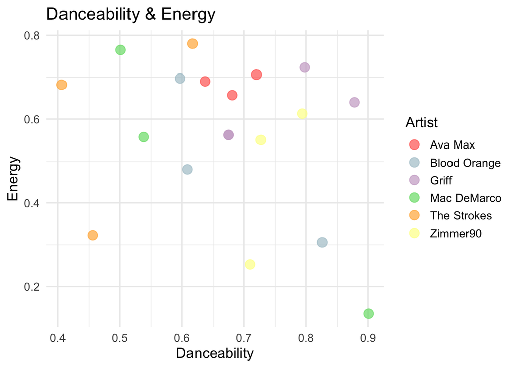

```r
library(ggplot2)

artist_colors <- c(
  "Blood Orange" = "#AEC6CF",
  "The Strokes" = "#FFB347",
  "Mac DeMarco" = "#77DD77",
  "Ava Max" = "#FF6961",
  "Griff" = "#CBAACB",
  "Zimmer90" = "#FDFD96"
)

ggplot(df %>% filter(!is.na(Artist)),
       aes(x = Danceability, y = Energy, color = Artist)) +
  geom_point(size = 4, alpha = 0.7) +
  scale_color_manual(values = artist_colors) +
  labs(
    title = "Danceability & Energy",
    x = "Danceability",
    y = "Energy"
  ) +
  theme_minimal(base_size = 14)
```

Conclusion: Energy x Danceability

A trend amongst Energy x Danceability can not be discovered.

### Tempo x Valence

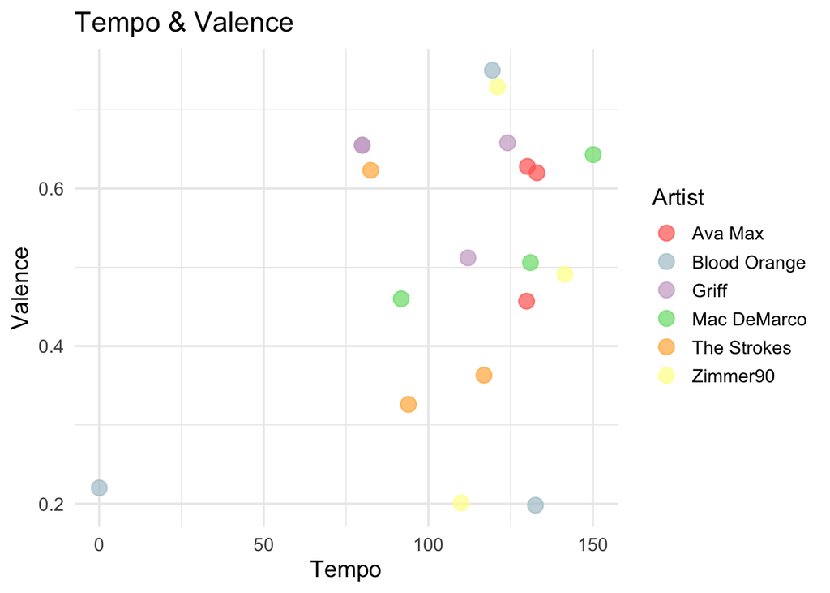

```r
# Creating a scatterplot based on instrumentalness and speechiness in pretty colours.

library(ggplot2)

artist_colors <- c(
  "Blood Orange" = "#AEC6CF",
  "The Strokes" = "#FFB347",
  "Mac DeMarco" = "#77DD77",
  "Ava Max" = "#FF6961",
  "Griff" = "#CBAACB",
  "Zimmer90" = "#FDFD96"
)

ggplot(df %>% filter(!is.na(Artist)),
       aes(x = Tempo, y = Valence, color = Artist)) +
  geom_point(size = 4, alpha = 0.7) +
  scale_color_manual(values = artist_colors) +
  labs(
    title = "Tempo & Valence",
    x = "Tempo",
    y = "Valence"
  ) +
  theme_minimal(base_size = 14)
```

Analysis: Tempo x Valence I have chosen to combine tempo and valence into one scatterplot because I may have a preference for emotionally ambigious movement with a higher tempo. For example, I do not enjoy very happy songs. Mac DeMarco, Griff and Ava Max all score quite high on Valence, where as Blood Orange and The Strokes score less high. Both Blood Orange and Zimmer 90, seek extremes which could be due to the ambigious nature of their songs. It can not be said that I prefer the tempo of my favourite artists over that of my non-favourite artists.

## Boxplots

Overall, not much information can be extracted from looking at scatterplots related to individual artists. Therefore, let us group the artists together into the categories: 1. Favourite Artists 2. Non-favourite Artists

```r
#Creating a new column called 'Preference' with my favourite artists and my least favourite artists.

library(dplyr)

favorite_artists <- c("The Strokes", "Zimmer90", "Blood Orange")
least_favorite_artists <- c("Ava Max", "Mac DeMarco", "Griff")

df <- df %>%
  mutate(Preference = case_when(
    Artist %in% favorite_artists ~ "Favorite",
    Artist %in% least_favorite_artists ~ "Least Favorite",
    TRUE ~ NA_character_ ))

#Checking whether an extra column has been created.
colnames(df)
```

```
 [1] "Song"             "Acousticness"     "Danceability"     "Energy"
 [5] "Instrumentalness" "Liveness"         "Loudness"         "Speechiness"
 [9] "Tempo"            "Valence"          "X"                "Artist"
[13] "Preference"
```

So, now that that extra column has been created, let us take a look at boxplots for:

1. Acousticness
2. Instrumentalness
3. Liveness
4. Valence

### Acousticness:

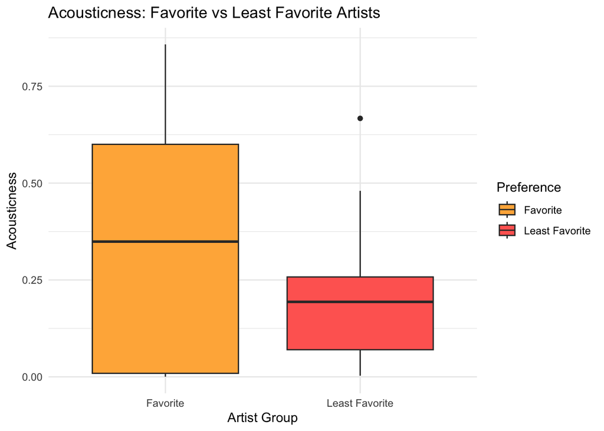

```r
# Creating a boxplot for acousticness based on my preference.

library(dplyr)
library(ggplot2)

df_filtered <- df %>%
  filter(!is.na(Preference))

ggplot(df_filtered, aes(x = Preference, y = Acousticness, fill = Preference)) +
  geom_boxplot() +
  scale_fill_manual(values = c(
    "Favorite" = "#FFB347",
    "Least Favorite" = "#FF6961"
  )) +
  labs(
    title = "Acousticness: Favorite vs Least Favorite Artists",
    x = "Artist Group",
    y = "Acousticness"
  ) +
  theme_minimal()
```

### Instrumentalness:

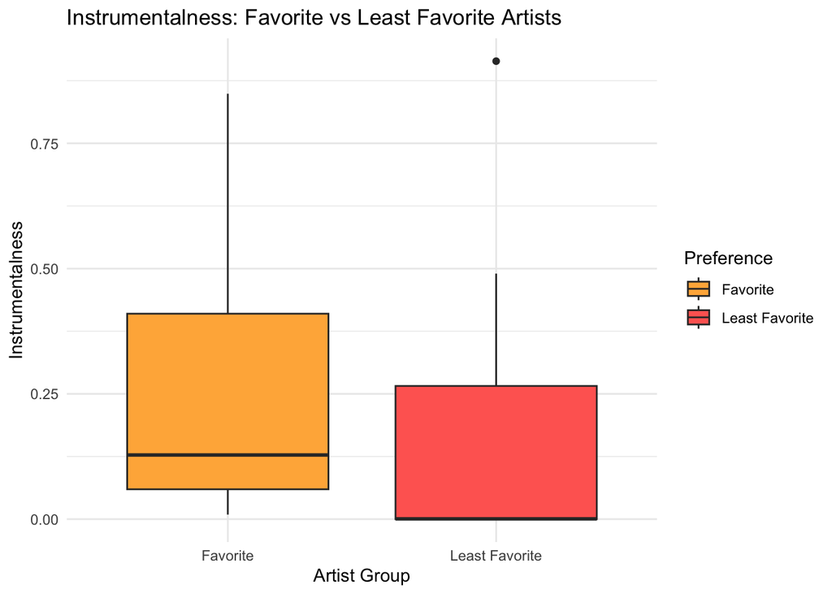

```r
# Creating a boxplot for instrumentalness based on my preference.

library(dplyr)
library(ggplot2)

df_filtered <- df %>%
  filter(!is.na(Preference))

ggplot(df_filtered, aes(x = Preference, y = Instrumentalness, fill = Preference)) +
  geom_boxplot() +
  scale_fill_manual(values = c(
    "Favorite" = "#FFB347",
    "Least Favorite" = "#FF6961"
  )) +
  labs(
    title = "Instrumentalness: Favorite vs Least Favorite Artists",
    x = "Artist Group",
    y = "Instrumentalness"
  ) +
  theme_minimal()
```

### Liveness:

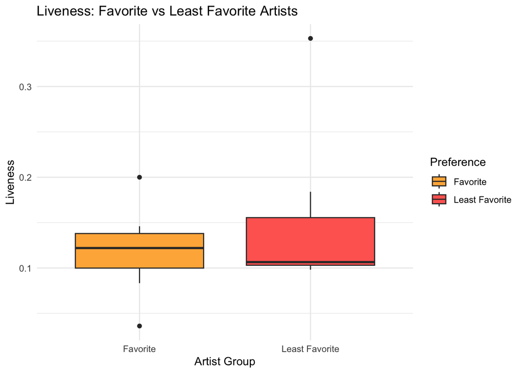

```r
# Creating a boxplot for Liveness based on my preference.

library(dplyr)
library(ggplot2)

df_filtered <- df %>%
  filter(!is.na(Preference))

ggplot(df_filtered, aes(x = Preference, y = Liveness, fill = Preference)) +
  geom_boxplot() +
  scale_fill_manual(values = c(
    "Favorite" = "#FFB347",
    "Least Favorite" = "#FF6961"
  )) +
  labs(
    title = "Liveness: Favorite vs Least Favorite Artists",
    x = "Artist Group",
    y = "Liveness"
  ) +
  theme_minimal()
```

### Valence:

Let us test our earlier conclusions about valence….

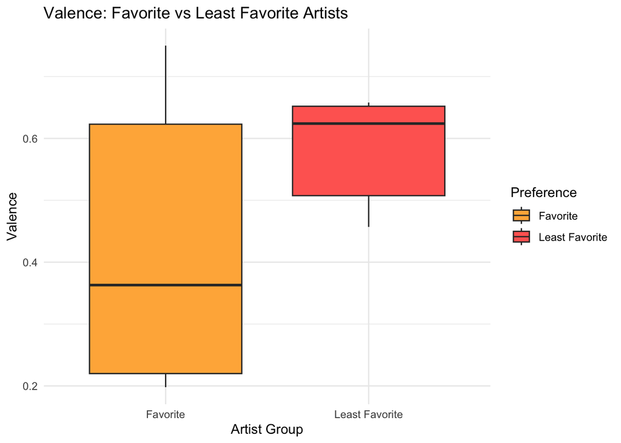

```r
#Creating a boxplot based on Valence

library(dplyr)
library(ggplot2)

df_filtered <- df %>%
  filter(!is.na(Preference))

ggplot(df_filtered, aes(x = Preference, y = Valence, fill = Preference)) +
  geom_boxplot() +
  scale_fill_manual(values = c(
    "Favorite" = "#FFB347",
    "Least Favorite" = "#FF6961"
  )) +
  labs(
    title = "Valence: Favorite vs Least Favorite Artists",
    x = "Artist Group",
    y = "Valence"
  ) +
  theme_minimal()
```

# Conclusion:

In conclusion, I care about some attributes more than others. Valence influences my taste much more than liveness for example. However, due to the small sample size of this analysis, a greater project could reveal more information.